# Take-Home Assignment

Dose Response Analysis

Yubing Wan, Ph.D.

22 Jan 2024

## Introduction

In pharmacology, a dose-response experiment determines the effects of a drug on cells grown in vitro.

This analysis consists of plotting X values that represent the drug concentrations or function of concentrations (log concentration) vs. Y values representing the response. The outcome is a sigmoidal curve (dose-response curve) with bottom and top plateaus (see below). It must be noted that these measured responses are end-point measurements. In other words, the response is measured after treating the biological system with different concentrations of the drug. The response is not measured at different times after treating the biological system with a single drug concentration.

## Four Parameter Logistic (4PL) Regression Model

The Hill Equation or 4 parameter logistic (4PL) model is a standard model often used in dose-response curve analysis. This non-linear regression model estimates 4 different parameters: Bottom (minimum response), Top (maximum response), Hill Slope and EC50. The parameters may be constrained (discussed later).

### Equation and Parameters of the 4PL Model

$$f(X, HillSlope, top, bottom, EC_{50}) = bottom + \frac{top - bottom}{1 +
10^{(Log(EC_{50}) - Log(X)) * HillSlope}}$$

1. Minimum response (Bottom). The Y value at the minimal curve asymptote (Bottom Plateau).
2. Maximum response (Top). The Y value at the maximum curve asymptote (Top Plateau).
3. Slop factor (also called Hill Slope). Defines the steepness of the dose-response curve. If the Hill slope <1, the sigmoidal curve is shallower. If Hill slope > 1 then the sigmoidal curve is steeper (see below). Constraining the slope value to 1.0 (standard Hill slope) or using a variable slope depends on the system and number of observations. If the number of observations is low, set the slope to 1.0. A variable slope is recommended for receptor-ligand binding assay analysis.
4. EC50 and IC50 values. EC50 (effective concentration) is the concentration of drug that elicits a response halfway between the baseline and maximum response (dose-response curves going upward) as seen below. IC50 (inhibitory concentration) is the concentration of a drug that elicits a response halfway between the maximum response and the minimum response, in downward-sloping dose-response curves. EC50 is influenced by a drug’s affinity and efficacy.

## Demo

### Code and Data

```r
if (!require("tidyverse", character.only = TRUE)) {
    install.packages("tidyverse", dependencies = TRUE)
    library("tidyverse", character.only = TRUE)
}

source(file.path(str_remove(getwd(), "/inst/rmd"), "R/funcs.R"))

## Define demo datasets
data_demo_stim <- data.frame(
  dose = c(1e-9 , 1e-8 , 1e-7 , 1e-6 , 1e-5 , 1e-4 , 1e-3 , 1e-2),
  response = c(0, 3, 8, 19, 31, 38, 40, 41))

data_demo_inhi <- data.frame(
  dose = c(1e-9 , 1e-8 , 1e-7 , 1e-6 , 1e-5 , 1e-4 , 1e-3 , 1e-2),
  response = rev(c(0, 3, 8, 19, 31, 38, 40, 41)))
```

### Inhibition

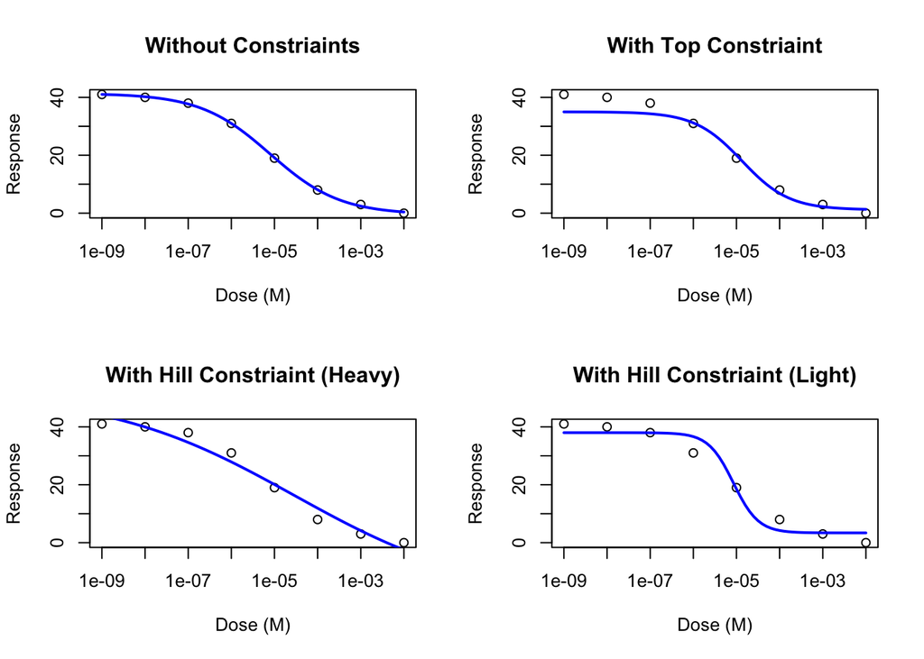

```r
m1 <- fit_4pl_model(data_demo_inhi)
m2 <- fit_4pl_model(data_demo_inhi, constr_top = 35, algorithm = "port")
m3 <- fit_4pl_model(data_demo_inhi, constr_h = -0.2, algorithm = "port")
m4 <- fit_4pl_model(data_demo_inhi, constr_h = -1.5, algorithm = "port")

par(mfrow = c(2, 2))
plot_dose_response_curve(m1, data_demo_inhi, main = "Without Constriaints")
plot_dose_response_curve(m2, data_demo_inhi, main = "With Top Constriaint")
plot_dose_response_curve(m3, data_demo_inhi, main = "With Hill Constriaint (Heavy)")
plot_dose_response_curve(m4, data_demo_inhi, main = "With Hill Constriaint (Light)")
```

### Stimulation

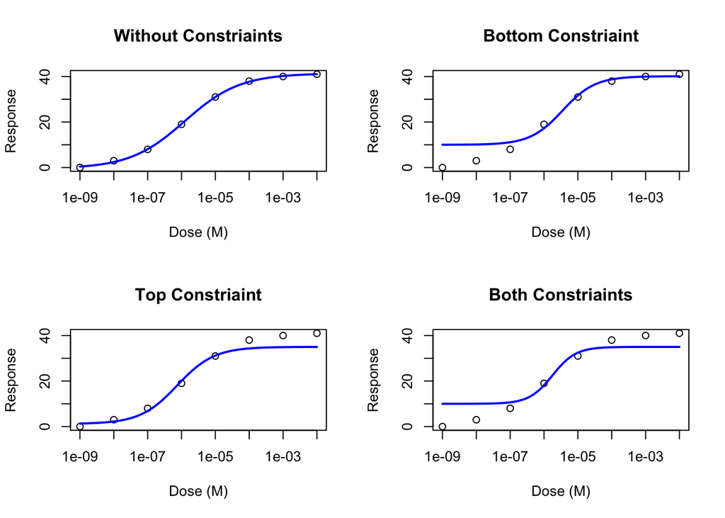

```r
m1 <- fit_4pl_model(data_demo_stim)
m2 <- fit_4pl_model(data_demo_stim, constr_bottom = 10, algorithm = "port")
m3 <- fit_4pl_model(data_demo_stim, constr_top = 35, algorithm = "port")
m4 <- fit_4pl_model(data_demo_stim, constr_bottom = 10, constr_top = 35, algorithm = "port")

par(mfrow = c(2, 2))
plot_dose_response_curve(m1, data_demo_stim, main = "Without Constriaints")
plot_dose_response_curve(m2, data_demo_stim, main = "Bottom Constriaint")
plot_dose_response_curve(m3, data_demo_stim, main = "Top Constriaint")
plot_dose_response_curve(m4, data_demo_stim, main = "Both Constriaints")
```

## Simulations and Cross-Software Validation - Python

### Inhibition

#### R

```r
set.seed(123) # For reproducibility
inhibition_data <- simulate_dose_response_data(type = "inhibition")
source_python(file.path(str_remove(getwd(), "/inst/rmd"), "script/funcs.py"))
py$dose <- inhibition_data$dose
py$response <- inhibition_data$response
fit <- fit_4pl_model(inhibition_data, ec50 = 50, h=1, top = 100)
```

#### Python

```python
fit_py = fit_4pl_model_py(dose, response)
```

```python
fitted_response = calculate_fitted_response(dose, fit_py)
```

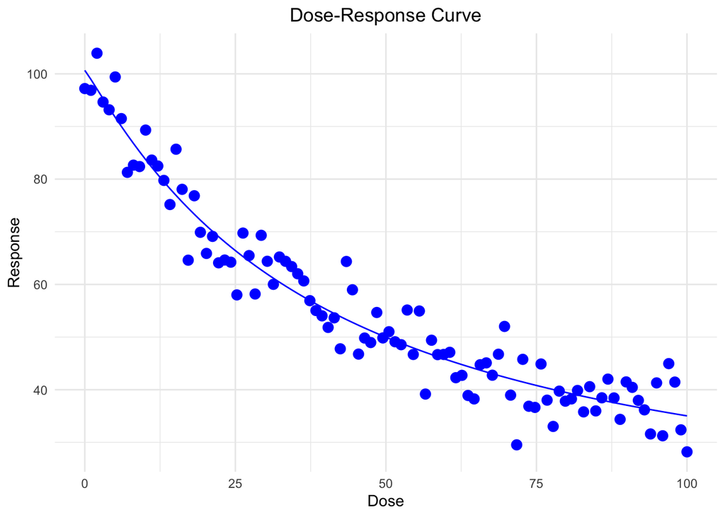

```r
plot_dose_response_with_fit(inhibition_data, coef = fit)
```

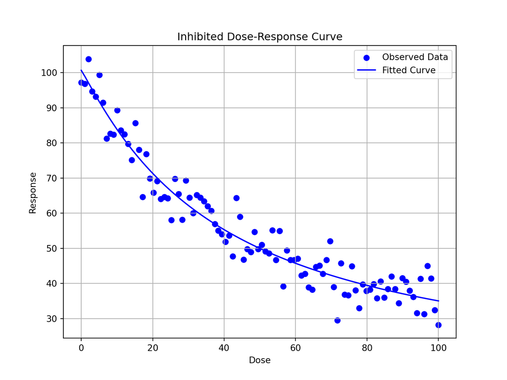

Parameter Estimates from R and Python (Inhibition)

|  | Estimates_R | Estimates_Python |
| --- | --- | --- |
| ec50 | 38.911765 | 38.910761 |
| h | 1.077137 | 1.077165 |
| top | 11.291335 | 11.292869 |
| bottom | 100.659048 | 100.658666 |

```python
plot_dose_response_with_fit_py(dose, response, fitted_response, title="Inhibited Dose-Response Curve")
```

### Stimulation

#### R

```r
stimulation_data <- simulate_dose_response_data(type = "stimulation")
# fit_drm <- dose_response_analysis(stimulation_data, response_type = "stimulation", constrained = T)
# fit_drm$coefficients
fit_r <- fit_4pl_model(stimulation_data, ec50 = 50, h=1, top = 100)
py$dose <- stimulation_data$dose
py$response <- stimulation_data$response
```

#### Python

```python
fit_py = fit_4pl_model_py(dose, response)
fitted_response = calculate_fitted_response(dose, fit_py)
```

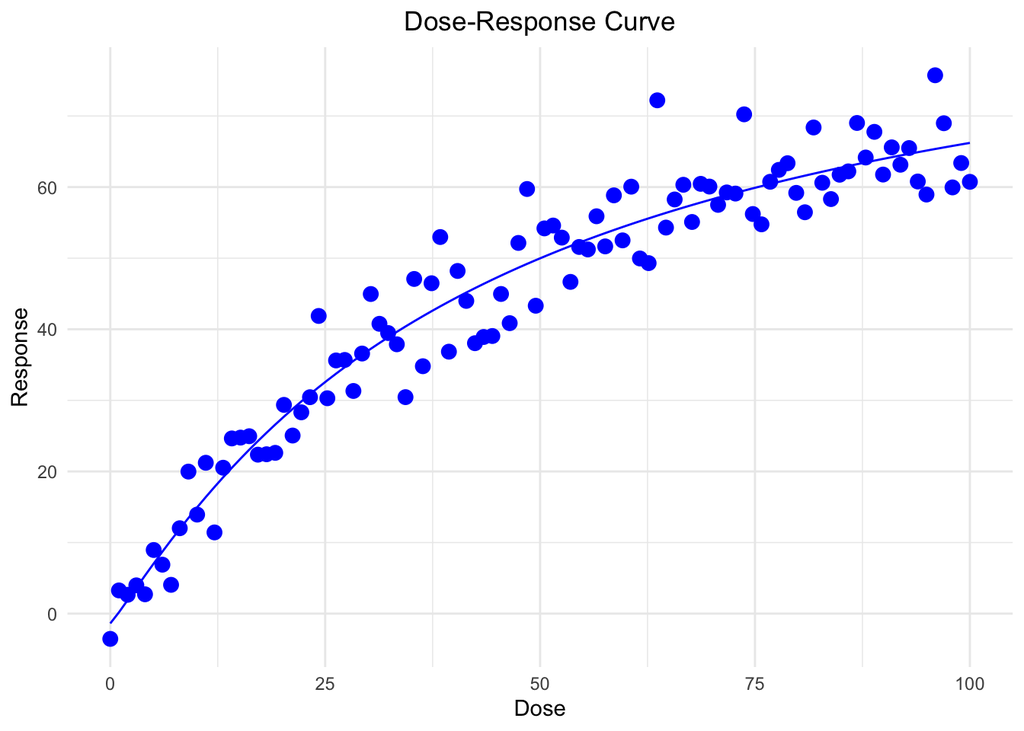

[figure not shown]

Parameter Estimates from R and Python (Stimulation)

|  | Estimates_R | Estimates_Python |
| --- | --- | --- |
| ec50 | 41.928435 | 41.928438 |
| h | 1.093523 | 1.093523 |
| top | 92.342830 | 92.342836 |
| bottom | -1.377560 | -1.377563 |

```r
plot_dose_response_with_fit(stimulation_data, coef = fit_r)
```

```python
# dose, response = simulate_dose_response(response_type='inhibition')
# fit_py = fit_4pl_model_py(dose, response)
# fitted_response = calculate_fitted_response(dose, fit_py)
# plot_dose_response_with_fit(dose, response, fitted_response, title="Inhibited Dose-Response Curve")
```

```python
# dose, response = simulate_dose_response(response_type='stimulation')
# fit_py = fit_4pl_model_py(dose, response)
# fitted_response = calculate_fitted_response(dose, fit_py)
# plot_dose_response_with_fit(dose, response, fitted_response, title="Simulated Dose-Response Curve", color = "red")
```